# Practical Machine Learning- Peer Graded Assignment

ISY

1/17/2021

# Part 0: Setup

```r
library(caret)
library(rpart)
library(randomForest)
library(gbm)
library(rattle)
```

# Part 1: Loading data

In this assignment, we will be working on a prediction model on a variable with given datasets. We will first download and upload datasets to our R environment

```r
url_train <- "https://d396qusza40orc.cloudfront.net/predmachlearn/pml-training.csv"
url_valid <- "https://d396qusza40orc.cloudfront.net/predmachlearn/pml-testing.csv"

download.file(url_train, destfile = paste0(getwd(), "/", "train_data.csv"))
download.file(url_valid, destfile = paste0(getwd(), "/", "valid_data.csv"))

train <- read.csv(paste0(getwd(), "/", "train_data.csv"))
valid <- read.csv(paste0(getwd(), "/", "valid_data.csv"))
```

Our goal is to create a model to predict “classe” variable. Since we have downloaded our datasets, we will first clean our data. We will start by removing case-identifying variables.

```r
train <- train[, -(1:5)]
valid <- valid[, -(1:5)]
```

Since we have some variables that NA or missing value proportion is high, we will remove those variables.

```r
var2rm_train <- c()

for (i in 1:ncol(train)) {
     if (sum(is.na(train[[i]]))/nrow(train)> 0.9 | sum(train[i] == "")/nrow(train) > 0.9)
     {
          var2rm_train <- c(var2rm_train, i)
     }
}

var2rm_train <- unique(var2rm_train)

# Same for test valid data

var2rm_valid <- c()

for (i in 1:ncol(valid)) {
     if (sum(is.na(valid[[i]]))/nrow(valid)> 0.9 | sum(valid[i] == "")/nrow(valid) > 0.9)
     {
          var2rm_valid <- c(var2rm_valid, i)
     }
}

var2rm_valid <- unique(var2rm_valid)

train <- train[, -var2rm_train]
valid <- valid[, -var2rm_valid]

#
```

# Part 2: Preparing Data For Prediction

We will divide our *train* data into train and test data.

```r
set.seed(33245)
inTrain <- createDataPartition(train$classe, p = 0.7, list = FALSE)
trainData <- train[inTrain,]
testData  <- train[-inTrain,]
```

# Part 3: Modelling

In order to avoid overfitting as much as possible, we will use **cross-validation** technique. We will use 5 folds for memory efficiency.

We will test 3 different modelling method: “classification tree”, “random forest” and “boosting”. At the end, we will check if it is feasible to combine all models.

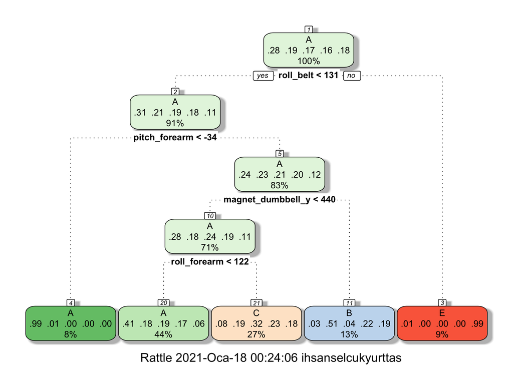

```r
fit1 <- train(factor(classe)~., data=trainData, method = "rpart", trControl = trainControl(method = "cv", number = 5))
fancyRpartPlot(fit1$finalModel)
```

```r
pred1 <- predict(fit1, testData)
cfmatrix1 <- confusionMatrix(factor(testData$classe), pred1)
cfmatrix1$table
```

```
##           Reference
## Prediction    A    B    C    D    E
##          A 1513   22  138    0    1
##          B  476  395  268    0    0
##          C  463   31  532    0    0
##          D  421  181  362    0    0
##          E  169  153  287    0  473
```

```r
cfmatrix1$overall[1]
```

```
##  Accuracy
## 0.4949873
```

Moving onto the random forest method.

```r
fit2 <- train(factor(classe)~., data=trainData, method = "rf",
              trControl = trainControl(method = "cv", number = 5), verbose=FALSE)
fit2$finalModel
```

```
##
## Call:
##  randomForest(x = x, y = y, mtry = param$mtry, verbose = FALSE)
##                Type of random forest: classification
##                      Number of trees: 500
## No. of variables tried at each split: 28
##
##         OOB estimate of  error rate: 0.22%
## Confusion matrix:
##      A    B    C    D    E  class.error
## A 3905    0    0    0    1 0.0002560164
## B    8 2646    4    0    0 0.0045146727
## C    0    4 2392    0    0 0.0016694491
## D    0    0    7 2244    1 0.0035523979
## E    0    1    0    4 2520 0.0019801980
```

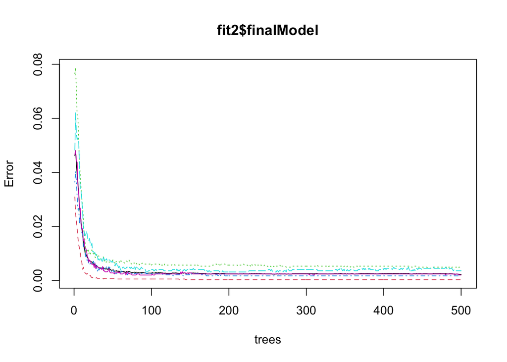

```r
plot(fit2$finalModel)
```